# Part II - (Impact of Parenting on Student's Performance)

## by (Oluwajuwon Oyalude)

## Investigation Overview

> In this presentation, I demonstrate find how parental availability may affect/influence students performance.

## Dataset Overview

> The dataset I analyzed contains information about 649 students performance in a portuguese subject with some information on their parental background.

## Distribution of Average Grades

> The Average Grades of the students ranges from 0 - 20. The distribution of the Average Grades is approximately normal, appears to be slightly skewed to the left. This shows that some students had incredibly low scores.

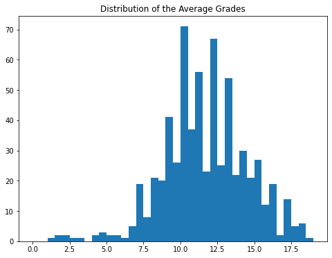

## Distribution of Guardians

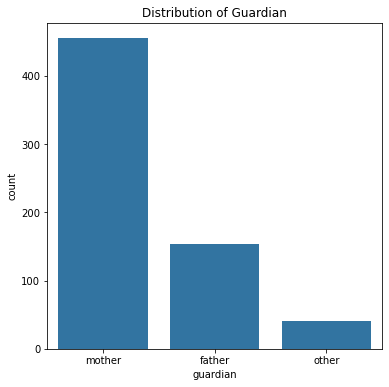

## Average Score vs Guardian

Even though there are many who have their mothers as their guardians (seen in previous plot), students who have their fathers as their guardians performed better generally. This is shown by comparing the median scores. Nevertheless, this didn't stop the former from getting the highest grades. Also worthy of note is that students who had neither of their parents (father or mother) as their guardian had the worst performace.

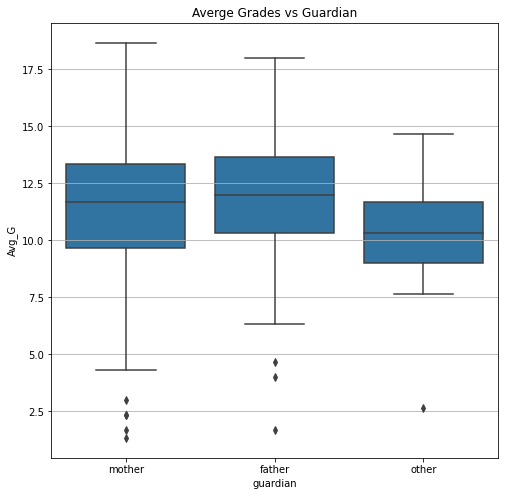